# Project 4 Report - Movie Recommendation

Team MAK :

- Mriganka Sarma (netID: ms76)

- Ajay Menon (netID: kamenon2)

- Kai Pak (netID: kaipak2)

5/9/2021

#### URL: https://teammak.shinyapps.io/project4/

A second URL that has the same deployment is provided as a backup  
URL (2): https://makteam.shinyapps.io/Project4/

```r
knitr::opts_chunk$set(echo = TRUE)
```

### Objective

The objective of this project is to build two systems for movie recommendation using the **MovieLens 1M Dataset**. The dataset contains about 1 million anonymous ratings of approximately 3,900 movies made by 6,040 MovieLens users who joined MovieLens in 2000. We’ll build two systems:

- **System I** - will recommend movies based on **genres**.
- **System II** - will be a **collaborative recommendation** system.

For each of the systems, we’ll explore two algorithms.

### Library Setup

```r
library(dplyr)
library(ggplot2)
library(DT)
library(data.table)
library(reshape2)
library(recommenderlab)

set.seed(1234)
```

### Data Preprocessing

We first downloaded the movies and ratings dataset to the data folder. Next we read in the dataset from the data folder.  
For the ratings data, we remove the ‘Timestamp’ column as it doesn’t seem to be a contributing factor.

```r
#myurl = "https://liangfgithub.github.io/MovieData/"
#ratings = read.csv(paste0(myurl, 'ratings.dat?raw=true'), sep = ':', colClasses = c('integer', 'NULL'), header = FALSE)

ratings = read.csv('data/ratings.dat', sep = ':', colClasses = c('integer', 'NULL'), header = FALSE)
colnames(ratings) = c('UserID', 'MovieID', 'Rating', 'Timestamp')
ratings$Timestamp = NULL # Timestamp doesn't seem to be a contributing factor
```

In the movies data, some movie names contain single colon (:), so the above method doesn’t work. So we split the movies data columns by using explicit separator (::) and then form the movies data matrix. Further, any accented characters are converted to UTF-8 encoding.

```r
# Movie pre-processing
#movies = readLines(paste0(myurl, 'movies.dat?raw=true'))
movies = readLines('data/movies.dat')
movies = strsplit(movies, split = "::", fixed = TRUE, useBytes = TRUE)
movies = matrix(unlist(movies), ncol = 3, byrow = TRUE)
movies = data.frame(movies, stringsAsFactors = FALSE)
colnames(movies) = c('MovieID', 'Title', 'Genres')
movies$MovieID = as.integer(movies$MovieID) # convert char to integer

# convert accented characters
movies$Title = iconv(movies$Title, "latin1", "UTF-8")
# extract year
movies$Year = as.numeric(unlist(lapply(movies$Title, function(x) substr(x, nchar(x)-4, nchar(x)-1))))
```

### Movies dataset

Here’s a look at the movies dataset.

```r
head(movies, 6)
```

```
##   MovieID                              Title                       Genres Year
## 1       1                   Toy Story (1995)  Animation|Children's|Comedy 1995
## 2       2                     Jumanji (1995) Adventure|Children's|Fantasy 1995
## 3       3            Grumpier Old Men (1995)               Comedy|Romance 1995
## 4       4           Waiting to Exhale (1995)                 Comedy|Drama 1995
## 5       5 Father of the Bride Part II (1995)                       Comedy 1995
## 6       6                        Heat (1995)        Action|Crime|Thriller 1995
```

### Ratings dataset

Here’s a look at the ratings dataset.

```r
head(ratings, 6)
```

```
##   UserID MovieID Rating
## 1      1    1193      5
## 2      1     661      3
## 3      1     914      3
## 4      1    3408      4
## 5      1    2355      5
## 6      1    1197      3
```

### System I

#### System I, Approach 1 - Recommendation based on Genres (Using Weighted score, shrinkage estimator)

For System I, Approach 1, we use a slightly modified weighted ratings method based off of IMDB’s approach which is used to display top 250 movies on their main website. The weighted score is produced by the following equation:

$$WR = (\frac{v}{v+m}) * R + (\frac{m}{v+m})*C$$
where,

- $R=$ mean rating
- $v=$ number of votes
- $m=$ minimum votes to appear in top 250
- $C=$ mean rating across corpus of movies

The modification to this scoring method is to base the means of $R$ and $C$ within specific genres. IMDB also sets a value for $m$ based on the minimum number of votes for a movie to appear in top 250 which is currently at 25,000. In our implementation, $m$ is determined on minimum number of votes to appear in top 50 of genre. We did not use the 25,000 vote threshold IMDB uses, because some genres, such as documentaries have far fewer votes than more popular ones and could produce some odd results.

The idea behind this rating system is to give more weight to the individual movie’s ratings the more votes they receive, otherwise, the corpus average is more heavily weighted. This is commonly and somewhat colloquially referred to as a Bayesian average as it is using an averaged prior across the corpus (in this case, the specific genre).

For our application, the weighted average scores are produced for every movie in the chosen genre with the top 10 ranked displayed in the interface.

#### References:

- https://help.imdb.com/article/imdb/track-movies-tv/ratings-faq/G67Y87TFYYP6TWAV#
- https://en.wikipedia.org/wiki/Bayesian_average

```r
get_top_rated_movies_in_genre_weighted <- function(selected_genre, count=10, my_top_n=50) {

  if (!is.na(selected_genre)) {
    filtered_movies_genre <- movies %>% filter(grepl(selected_genre, Genres))
  } else {
    filtered_movies_genre <- movies
  }

  ratings_in_genre <- ratings %>%
    group_by(MovieID) %>%
    summarize(ratings_per_movie = n(), ave_ratings = round(mean(Rating), dig=3)) %>%
    inner_join(filtered_movies_genre, by = 'MovieID')
  C <- mean(ratings_in_genre$ave_ratings)

  top_votes <- ratings_in_genre %>%
    top_n(my_top_n, ratings_per_movie) %>%
    arrange(desc(ratings_per_movie))
  m <- min(top_votes$ratings_per_movie)

  top_rated_in_genre <-
    mutate(ratings_in_genre, weighted_rating =
      (ratings_per_movie /  (ratings_per_movie + m)) * ave_ratings +
      (m / (ratings_per_movie + m)) * C) %>%
    top_n(count, weighted_rating) %>%
    arrange(desc(weighted_rating))

  return(top_rated_in_genre)
}
selected_genre = "Comedy" # Say this is what the user selected
top_10_movies <- get_top_rated_movies_in_genre_weighted(selected_genre, count = 10)
top_10_movies
```

```
## # A tibble: 10 x 7
##    MovieID ratings_per_movie ave_ratings Title    Genres    Year weighted_rating
##      <int>             <int>       <dbl> <chr>    <chr>    <dbl>           <dbl>
##  1    2858              3428        4.32 America… Comedy|…  1999            4.02
##  2    1197              2318        4.30 Princes… Action|…  1987            3.91
##  3    1136              1599        4.34 Monty P… Comedy    1974            3.83
##  4    2396              2369        4.13 Shakesp… Comedy|…  1998            3.80
##  5    2997              2241        4.12 Being J… Comedy    1999            3.79
##  6       1              2077        4.15 Toy Sto… Animati…  1995            3.78
##  7    3114              1585        4.22 Toy Sto… Animati…  1999            3.76
##  8     356              2194        4.09 Forrest… Comedy|…  1994            3.76
##  9    2324              1152        4.33 Life Is… Comedy|…  1997            3.73
## 10    1304              1419        4.22 Butch C… Action|…  1969            3.73
```

#### System I, Approach 2 - Based on popularity using recommenderlab

For System I, Approach 2, we have used the method = POPULAR to create our recommender object. The idea here is to show the users the most popular movies and take help from top users who have rated multiple movies as they would seem to be more engaged in the movie review process. Since system 1 doesn’t have the logged-in user preferences, it doesn’t matter which users are selected as long as those users are highly engaged.

**Note**: We have not taken year of make into consideration, since user may prefer to watch old but good movies. Also this implementation does have a slower performance compared to system 1, approach 1 since the Rating Matrix(Rmat) in spite of being filtered down by genre and top users, is still quite big.

**a)** We have first defined how the utility matrix should be created.  
**b)** Since the requirement for system 1 is based on the selected ‘Genre’, it seemed very important to filter out movies of specific Genre first. For this we have used ‘grepl’ function to filter out the movies.  
**c)** A list of say 2000 top users who have given the most ratings is retrieved.  
**d)** recom_ratings - this realRatingMatrix object would store complete ratings (Actual / Predicted) and for that ‘ratingMatrix’ type is set. The dataframe will be further modifed for user and item to UserID and MovieID settings.  
**e)** recom_topNList - this type would help us get the top 10 recommended movies by the top users.  
**f)** recom_ratings_df.new.grouped - since the predicted ratings can cross 5 or be negative, we have simply taken average here.  
**g)** Finally top 10 rated recommended movies are displayed and it did seem to reflect top rated movies (8.0) and above on actual IMDB site as well.

#### Create a utitlity matrix

```r
create_utility_matrix <- function(input_data) {
  i = paste0('u', input_data$UserID)
  j = paste0('m', input_data$MovieID)
  x = input_data$Rating
  tmp = data.frame(i, j, x, stringsAsFactors = T)
  Rmat = sparseMatrix(as.integer(tmp$i), as.integer(tmp$j), x = tmp$x)
  rownames(Rmat) = levels(tmp$i)
  colnames(Rmat) = levels(tmp$j)
  Rmat = new('realRatingMatrix', data = Rmat)
  return (Rmat)
}
```

```r
get_top_users_rated_movies <- function (selected_genre, count = 2000) {

  #filter the movies by genre as usual
  filtered_movies_genre <- movies %>% filter(grepl(selected_genre, Genres))
  # use ratings from user who might have reviewed the same genre.
  filtered.ratings <- ratings %>% filter(MovieID %in% filtered_movies_genre$MovieID)

  top_users_rated_movies <- filtered.ratings %>% group_by(MovieID) %>%
    summarize(ratings_per_movie = n(), ave_ratings = round(mean(Rating), dig=3)) %>%
    filter(ratings_per_movie > 1000) %>%
    top_n(count, ave_ratings) %>%
    arrange(desc(ave_ratings))

  return (top_users_rated_movies)
}

get_top_rated_movies_based_on_popularity <- function(selected_genre, count=10) {

   #filter the movies by genre as usual
  filtered_movies_genre <- movies %>% filter(grepl(selected_genre, Genres))
  # use ratings from user who might have reviewed the same genre.
  filtered.ratings <- ratings %>% filter(MovieID %in% filtered_movies_genre$MovieID)

  ## select top users who have rated the specific genre:
  top_users <- get_top_users_rated_movies(selected_genre, count = 2000)
  filtered.ratings <- filtered.ratings %>% filter(MovieID %in% top_users$MovieID)

  # Utility matrix creation
  Rmat <- create_utility_matrix(filtered.ratings)

  # POPULAR - Model creation
  rec_popular = Recommender(Rmat, method="POPULAR")

  # Complete predicted matrix (including original ratings by users).
  recom_ratings = predict(rec_popular, Rmat,type = 'ratingMatrix')
  recom_ratings_df = as(recom_ratings,'data.frame')

  #clean up df
  recom_ratings_df.new <- recom_ratings_df
  recom_ratings_df.new$user <- as.numeric(sub('.', '', (recom_ratings_df$user)))
  recom_ratings_df.new$item <- as.numeric(sub('.', '', (recom_ratings_df$item)))
  colnames(recom_ratings_df.new) <- c('UserID', 'MovieID', 'Pred.Rating')

  # Return top-N recomendations. Extract results from recom_topNlist object
  recom_topNList = predict(rec_popular, Rmat, n = 10, type = 'topNList')
  best_10_df <- (as(bestN(recom_topNList, n = 10), 'list'))
  best_10_unique_movies <- list()
  for (i in 1:length(best_10_df)) {
    best_10_unique_movies <- append(best_10_unique_movies, best_10_df[[i]])
  }
  best_10_unique_movies <- unlist((unique(best_10_unique_movies)))
  best_10_unique_movies <- as.numeric(sub('.', '', (best_10_unique_movies)))

  # group by predicted/actual ratings and retrieve top-10. here I have averaged the predicted
  # ratings such that different movies could come up in the list
  recom_ratings_df.new <- recom_ratings_df.new %>% filter(MovieID %in% best_10_unique_movies)
  recom_ratings_df.new.grouped <- recom_ratings_df.new %>% group_by(MovieID) %>%
    summarize(ratings_per_movie = n(), ave_ratings = round(mean(Pred.Rating), dig=3)) %>%
    top_n(count, ave_ratings) %>% arrange(desc(ave_ratings))

  recom_ratings_df.new.grouped <- recom_ratings_df.new.grouped %>% inner_join(movies, by='MovieID')

  top_rated_in_genre <- data.table(Rank = 1:10, MovieID = recom_ratings_df.new.grouped$MovieID,
                          Title = recom_ratings_df.new.grouped$Title,
                          Predicted_rating =  recom_ratings_df.new.grouped$ave_ratings)

  return(top_rated_in_genre)
}

selected_genre <- 'Comedy'
top_10_movies <- get_top_rated_movies_based_on_popularity(selected_genre, count = 10)
top_10_movies
```

```
##     Rank MovieID                                      Title Predicted_rating
##  1:    1    1234                          Sting, The (1973)            4.322
##  2:    2    1136     Monty Python and the Holy Grail (1974)            4.315
##  3:    3    2324 Life Is Beautiful (La Vita è bella) (1997)            4.299
##  4:    4    2858                     American Beauty (1999)            4.288
##  5:    5    1197                 Princess Bride, The (1987)            4.279
##  6:    6    1278                  Young Frankenstein (1974)            4.231
##  7:    7    2804                  Christmas Story, A (1983)            4.206
##  8:    8    1304  Butch Cassidy and the Sundance Kid (1969)            4.190
##  9:    9    3114                         Toy Story 2 (1999)            4.180
## 10:   10    1288                  This Is Spinal Tap (1984)            4.170
```

### System II - Recommendation based on Rating (UBCF, IBCF, SVD)

We have further used the packages/functions available in R for our system 2 implementation. We have tried to evaluate all the models based on RMSE, run-time, ROC, and balance of precision vs recall error.

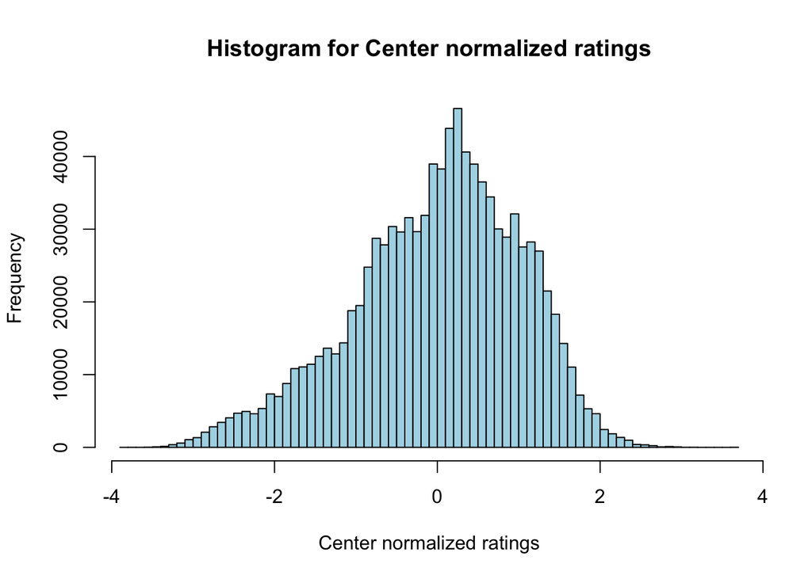

```r
Rmat = create_utility_matrix(ratings)
hist(getRatings(normalize(Rmat, method="Center")), breaks=100, col="lightblue",
     main="Histogram for Center normalized ratings",
     xlab="Center normalized ratings",
     border="black")
```

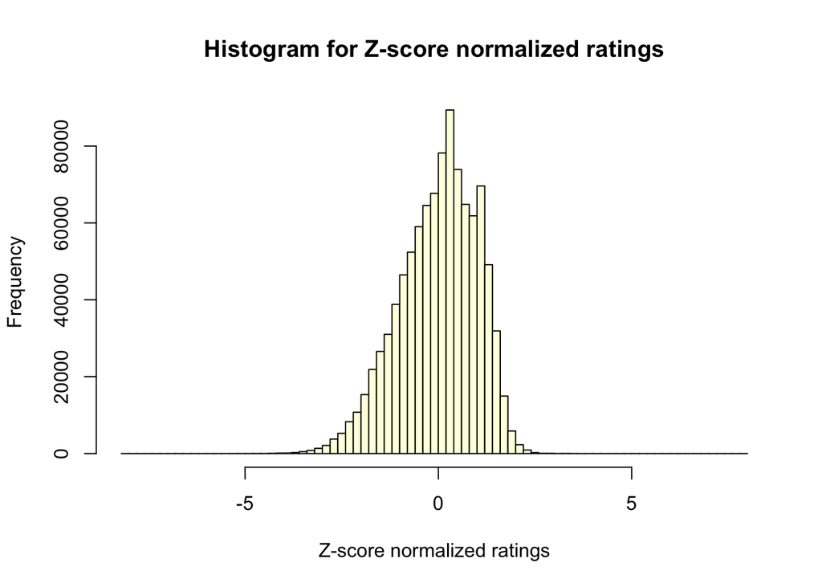

```r
hist(getRatings(normalize(Rmat, method="Z-score")), breaks =100, col="lightyellow",
     main="Histogram for Z-score normalized ratings",
     xlab="Z-score normalized ratings",
     border="black")
```

#### System II, Approach 1 - UBCF (User-based collaborative filtering)

##### Step 1: Retrieve top movies which have been heavily rated by different users.

This defines the popularity of such movies are high amongst the general population.

```r
retrieve_top_rated_users <- function(top_count=2000, is_unique_genre = TRUE, is_unique_movie=TRUE) {

  selected_genre <- NA # Since we need to collect all unique genres
  top_rated_movies <- get_top_rated_movies_in_genre_weighted(selected_genre, count=top_count)

  if (is_unique_genre) {
    top_rated_movies <- top_rated_movies %>% distinct(Genres, .keep_all = TRUE)
  }

  if (is_unique_movie) {
    top_rated_movies <- top_rated_movies %>%
      mutate(first_two_words_movie_name = sub("(\\w+\\s+\\w+).*", "\\1", Title)) %>%
      distinct(first_two_words_movie_name, .keep_all = TRUE)
  }

  return (top_rated_movies)
}

top_rated_movies_by_genre <- retrieve_top_rated_users()
filtered_top_rated_movies <- ratings %>% filter (ratings$MovieID %in% top_rated_movies_by_genre$MovieID)
```

##### Step 2: Collect User Input and Create new rating matrix

An additional step here can be introduced to further reduce selected genres based on user input.  
**Note**: Since it’s possible that user selects less number of movies, the filtering and then prediction may reduce the movies to such an extent that no movies are shown. Hence it’s avoided in actual implementation.

```r
# Below is a sample scenario
user_movie_ids <- c(608, 648, 3471) # user rated movie ids
user_movie_ratings <- c(4,3,5) # user input ratings


#ADDITIONAL STEP (not in actual server implementation):
#find the genre of these movies and filter further such movies from ratings
retrieve_unique_selected_genres <- function (user_movie_ids) {
  input_generes <- movies %>% filter (MovieID %in% user_movie_ids)
  input_genres_list <- tstrsplit(input_generes$Genres, '[|]', type.convert=TRUE)
  input_unique_genre_list <- list()

  for (i in 1:length(input_genres_list)) {
    input_unique_genre_list <- append(input_unique_genre_list, input_genres_list[[i]])
  }
  input_unique_genre_list <- input_unique_genre_list[!is.na(input_unique_genre_list)]
  input_unique_genre_list <- (unlist((unique(input_unique_genre_list))))

  return (input_unique_genre_list)
}

input_generes <- retrieve_unique_selected_genres(user_movie_ids)
input_generes # unique genres selected.
```

```
## [1] "Crime"     "Action"    "Drama"     "Adventure" "Sci-Fi"    "Thriller"
## [7] "Mystery"
```

```r
filtered_top_rated_movies <- filtered_top_rated_movies %>% inner_join(movies, by='MovieID') %>%
  filter(grepl(input_generes, Genres))
# remove the joined values
filtered_top_rated_movies$Title <- NULL
filtered_top_rated_movies$Genres <- NULL
filtered_top_rated_movies$Year <- NULL


#user id is purposefully kept at 0 such that it can come up in the rating list as the top element.
user_input = data.frame(UserID=0, MovieID=user_movie_ids, Rating = user_movie_ratings)
new.train <- rbind(user_input, filtered_top_rated_movies) # bring the user_input as top entry
user_util_mat <- create_utility_matrix(new.train)
```

##### Step 3: Run UBCF Analysis

```r
# UBCF Collaborative methods
create_ubcf_training <- function(input_data) {
  rec_UBCF = Recommender(data = input_data, method='UBCF', parameter =
                           list (normalize = 'Z-score', method = 'Cosine', nn = 25))
  return (rec_UBCF)
}

rec_model <- create_ubcf_training(user_util_mat)
# Predict ratings for the input user who is already top entry. user id = 0
recom = predict(rec_model, user_util_mat[1:1], n = 10,  type = 'topNList')

# We can also see the exact predicted ratings by using ratingMatrix. ratingMatrix will also fill up already predicted ones.
recom_ratingMat = predict(rec_model, user_util_mat[1:1], n = 10,  type = 'ratingMatrix')
recom_ratingMatDf = as(recom_ratingMat,'data.frame')
recom_ratingMatDf$user <- as.numeric(sub('.', '', (recom_ratingMatDf$user)))
recom_ratingMatDf$item <- as.numeric(sub('.', '', (recom_ratingMatDf$item)))
colnames(recom_ratingMatDf) = c('UserID', 'MovieID', 'Pred.Rating')

best_10 = as(bestN(recom, n = 10), 'list')

user_predicted_ids = suppressWarnings(as.numeric(sub('.', '', (best_10[[1]]))))
final_filtered_movies <- movies[movies$MovieID %in% user_predicted_ids,]
final_filtered_movies <- final_filtered_movies %>% inner_join(recom_ratingMatDf, by='MovieID') %>%
  arrange(desc(Pred.Rating))

recom_results <- data.table(Rank = 1:10,
                            MovieID = final_filtered_movies$MovieID,
                            Title = final_filtered_movies$Title,
                            Predicted_rating =  final_filtered_movies$Pred.Rating)

recom_results
```

```
##     Rank MovieID                        Title Predicted_rating
##  1:    1    1732     Big Lebowski, The (1998)         4.968246
##  2:    2      50   Usual Suspects, The (1995)         4.717692
##  3:    3     858        Godfather, The (1972)         4.322749
##  4:    4    1234            Sting, The (1973)         4.322749
##  5:    5    1645 Devil's Advocate, The (1997)         4.322749
##  6:    6     296          Pulp Fiction (1994)         4.128857
##  7:    7    1179         Grifters, The (1990)         4.000000
##  8:    8    1248         Touch of Evil (1958)         4.000000
##  9:    9    1396              Sneakers (1992)         4.000000
## 10:   10    1589              Cop Land (1997)         4.000000
```

#### System II, Approach 2 - IBCF (Item-based collaborative filtering)

Only movies which have been rated again by top-rating-users are selected here. No additional filtering is done here. Item-to-Item similarity provides more reliable information because it’s easier to find items in the same genre than it’s to find users that like items of a single genre.

##### Step 1: Collect User Input and Create new rating matrix as usual

```r
top_rated_movies_by_genre <- retrieve_top_rated_users()
filtered_top_rated_movies <- ratings %>% filter (ratings$MovieID %in% top_rated_movies_by_genre$MovieID)

# Below is a sample input scenario
user_movie_ids <- c(608, 648, 3471) # user rated movie ids
user_movie_ratings <- c(4,3,5) # user input ratings

#user id is purposefully kept at 0 such that it can come up in the rating list as the top element.
user_input = data.frame(UserID=0, MovieID=user_movie_ids, Rating = user_movie_ratings)
new.train <- rbind(user_input, filtered_top_rated_movies) # bring the user_input as top entry
user_util_mat <- create_utility_matrix(new.train)
```

##### Step 2: IBCF training and predicition

```r
create_ibcf_training <- function(input_data) {
  rec_IBCF = Recommender(data = input_data, method='IBCF', parameter =
                           list (normalize = 'Z-score', method = 'Cosine'))
  return (rec_IBCF)
}

rec_model_ibcf <- create_ibcf_training(user_util_mat)
rec_model_ibcf
```

```
## Recommender of type 'IBCF' for 'realRatingMatrix'
## learned using 6031 users.
```

```r
# Predict ratings for the input user who is already top entry. user id = 0
recom_topNList = predict(rec_model_ibcf, user_util_mat[1:1], n = 10,  type = 'topNList')

# We can also see the exact predicted ratings by using ratingMatrix. ratingMatrix will also fill up already predicted ones.
recom_ratingMatIBCF = predict(rec_model_ibcf, user_util_mat[1:1], n = 10,  type = 'ratingMatrix')
recom_ratingMatIBCFDf = as(recom_ratingMatIBCF,'data.frame')
recom_ratingMatIBCFDf$user <- as.numeric(sub('.', '', (recom_ratingMatIBCFDf$user)))
recom_ratingMatIBCFDf$item <- as.numeric(sub('.', '', (recom_ratingMatIBCFDf$item)))
colnames(recom_ratingMatIBCFDf) = c('UserID', 'MovieID', 'Pred.Rating')

best_10 = as(bestN(recom_topNList, n = 10), 'list')

user_predicted_ids = suppressWarnings(as.numeric(sub('.', '', (best_10[[1]]))))
final_filtered_movies <- movies[movies$MovieID %in% user_predicted_ids,]
final_filtered_movies <- final_filtered_movies %>% inner_join(recom_ratingMatIBCFDf, by='MovieID') %>%
  arrange(desc(Pred.Rating))

recom_results <- data.table(Rank = 1:10,
                            MovieID = final_filtered_movies$MovieID,
                            Title = final_filtered_movies$Title,
                            Predicted_rating =  final_filtered_movies$Pred.Rating)

recom_results
```

```
##     Rank MovieID                                    Title Predicted_rating
##  1:    1    1097        E.T. the Extra-Terrestrial (1982)                5
##  2:    2    1387                              Jaws (1975)                5
##  3:    3    1910                       I Went Down (1997)                5
##  4:    4    1136   Monty Python and the Holy Grail (1974)                3
##  5:    5    1172                   Cinema Paradiso (1988)                3
##  6:    6    1197               Princess Bride, The (1987)                3
##  7:    7    1204                Lawrence of Arabia (1962)                3
##  8:    8    1219                            Psycho (1960)                3
##  9:    9    1248                     Touch of Evil (1958)                3
## 10:   10    1254 Treasure of the Sierra Madre, The (1948)                3
```

## Detailed Analysis

#### Mathematical Models

- UBCF Cosine Similarity as mentioned below gets similarity measures between two users $u_{x}$ and $u_{y}$ where $\overrightarrow{x}$ = $r_{x}$ and $\overrightarrow{y}$ = $r_{y}$ represent row vectors in R with two user’s profile vectors.

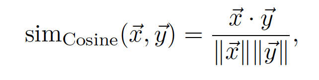

- IBCF Cosine similarity as show is as shown below and self explanatory

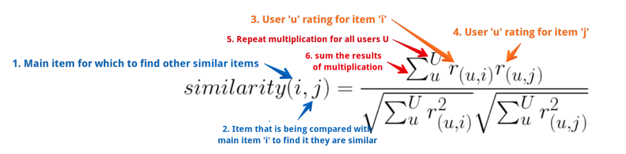

IBCF Cosine Similarity

#### RMSE (Residual Mean Square Error)

The Residual Mean Square Error (RMSE) is the error function that will measure accuracy and quantify the typical error we make when predicting the movie rating.

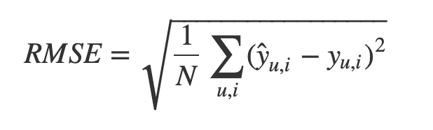

RMSE

#### Training and Testing Data

We split the data as 80% train and 20% test randomly first just to compare the results. Complete rating dataset used to created 6040 x 3706 rating matrix of class ‘realRatingMatrix’ with 1000209 ratings.

```r
#create train and test set
train.id = sample (nrow(ratings), floor(nrow(ratings)) * 0.8)  # Random split
train = ratings[train.id,]
test  = ratings[-train.id,]

Rmat.Complete <- create_utility_matrix(ratings)
Rmat.Train <- create_utility_matrix(train) # Randomly selected train set
Rmat.Test <- create_utility_matrix(test) # Randomly selected test set
```

### Evaluation Schemes

To evaluate recommender algorithms package recommenderlab provides the infrastructure to create and maintain evaluation schemes stored as an object of class **evaluationScheme** from ratings data. We have taken the complete ratings dataset for evaluationScheme.

- goodRating - Rating 3 and above were considered good ratings and below bad ratings.
- 5 k cross validations were considered.
- 15 movie/items were to be retained in test for each user.

```r
train_percent <- 0.9
n_folds <- 5  ## 5 iterations of run
to_keep <- 15  ## given 15 items (number of users to consider for the test set.)
good_threshold <- 3 ## ratings above 3 as the cutoff point
method <- "cross-validation" # other methods split, bootstrap

e.cross <- evaluationScheme(Rmat.Complete, method = "cross-validation", train = train_percent,
                            k = n_folds, given = to_keep, goodRating = good_threshold)

print(e.cross)
```

```
## Evaluation scheme with 15 items given
## Method: 'cross-validation' with 5 run(s).
## Good ratings: >=3.000000
## Data set: 6040 x 3706 rating matrix of class 'realRatingMatrix' with 1000209 ratings.
```

```r
cross.training <- getData(e.cross, "train")
cross.known <- getData(e.cross, "known")
cross.unknown <- getData(e.cross, "unknown")

print(paste0("Traing data has ", nrow(cross.training)," rows, users"))
```

```
## [1] "Traing data has 4832 rows, users"
```

```r
print(paste0("Known Testing data has ", nrow(cross.known)," rows, users"))
```

```
## [1] "Known Testing data has 1208 rows, users"
```

#### UBCF Train and Prediction using Cross-Recommender

```r
#Training
ubcf_cross_training_time <- system.time({
    r_model.ubcf.cross.train <- Recommender(getData(e.cross, "train"), "UBCF",
                                            parameter = list (normalize = 'Z-score', method = 'Cosine', nn = 25))
  })

#Model training time
print(ubcf_cross_training_time)
```

```
##    user  system elapsed
##   0.590   0.076   0.670
```

```r
print(r_model.ubcf.cross.train)
```

```
## Recommender of type 'UBCF' for 'realRatingMatrix'
## learned using 4832 users.
```

```r
# Prediction
ubcf_cross_prediction_time <- system.time({
  p1 <- predict(r_model.ubcf.cross.train, getData(e.cross, "known"), type="ratings")
})

print(p1)
```

```
## 1208 x 3706 rating matrix of class 'realRatingMatrix' with 1544277 ratings.
```

```r
print(ubcf_cross_prediction_time)
```

```
##    user  system elapsed
## 102.194   0.758 103.088
```

#### IBCF Train and Prediction using Cross-Recommender

```r
#Training
ibcf_cross_training_time <- system.time({
    r_model.ibcf.cross.train <- Recommender(getData(e.cross, "train"), "IBCF",
                                            parameter = list (normalize = 'Z-score', method = 'Cosine'))
  })

#Model training time
print(ibcf_cross_training_time)
```

```
##    user  system elapsed
## 246.546   1.218 248.670
```

```r
print(r_model.ibcf.cross.train)
```

```
## Recommender of type 'IBCF' for 'realRatingMatrix'
## learned using 4832 users.
```

```r
# Prediction
ibcf_cross_prediction_time <- system.time({
  p2 <- predict(r_model.ibcf.cross.train, getData(e.cross, "known"), type="ratings")
})

print(p2)
```

```
## 1208 x 3706 rating matrix of class 'realRatingMatrix' with 144510 ratings.
```

```r
print(ibcf_cross_prediction_time)
```

```
##    user  system elapsed
##   0.356   0.081   0.440
```

#### Error Analysis - UBCF vs IBCF

```r
error <- rbind(
  UBCF = calcPredictionAccuracy(p1, getData(e.cross, "unknown")),
  IBCF = calcPredictionAccuracy(p2, getData(e.cross, "unknown"))
)
error
```

```
##          RMSE      MSE       MAE
## UBCF 1.147394 1.316513 0.8875199
## IBCF 1.756760 3.086207 1.3833671
```

### Comparing top-N recommendations

```r
scheme <- evaluationScheme(Rmat.Complete, method="split", train = .8, k=5, given=10, goodRating=3)

algorithms <- list(
                   "random items" = list(name="RANDOM", param=NULL),
                   "popular items" = list(name="POPULAR", param=NULL),
                   "user-based CF" = list(name="UBCF", param=list(nn=25)),
                   "item-based CF" = list(name="IBCF", param=list(k=5)),
                   "SVD approximation" = list(name="SVD", param=list(k = 5)))

results <- evaluate(scheme, algorithms, type = "topNList", n=c(1, 3, 5, 10, 15, 20))
```

```
## RANDOM run fold/sample [model time/prediction time]
##   1  [0.005sec/3.79sec]
##   2  [0.014sec/4.446sec]
##   3  [0.015sec/3.453sec]
##   4  [0.005sec/2.82sec]
##   5  [0.005sec/3.204sec]
## POPULAR run fold/sample [model time/prediction time]
##   1  [0.055sec/26.013sec]
##   2  [0.06sec/30.052sec]
##   3  [0.1sec/29.74sec]
##   4  [0.156sec/20.643sec]
##   5  [0.052sec/18.813sec]
## UBCF run fold/sample [model time/prediction time]
##   1  [0.042sec/93.677sec]
##   2  [0.044sec/93.391sec]
##   3  [0.042sec/93.243sec]
##   4  [0.043sec/93.459sec]
##   5  [0.041sec/93.147sec]
## IBCF run fold/sample [model time/prediction time]
##   1  [196.617sec/0.323sec]
##   2  [196.687sec/0.322sec]
##   3  [196.489sec/0.282sec]
##   4  [224.107sec/0.76sec]
##   5  [209.84sec/0.315sec]
## SVD run fold/sample [model time/prediction time]
##   1  [3.583sec/2.864sec]
##   2  [3.541sec/2.727sec]
##   3  [3.598sec/2.775sec]
##   4  [3.579sec/2.534sec]
##   5  [3.558sec/2.701sec]
```

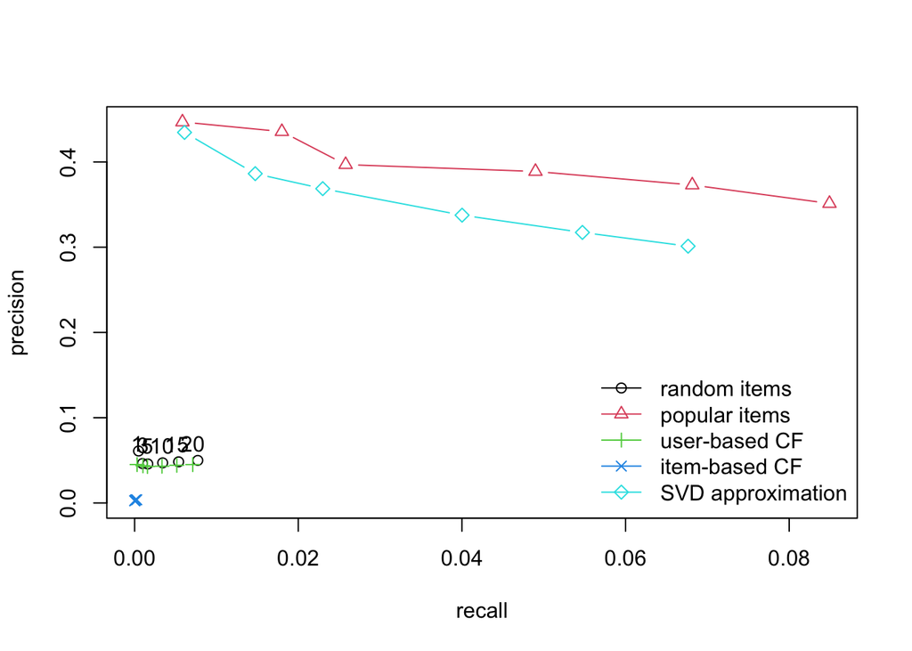

```r
plot(results, "prec/rec", annotate=3, legend="bottomright")
```

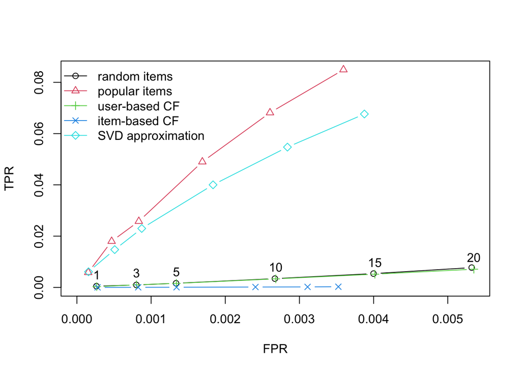

```r
plot(results, "ROC", annotate=3, legend="topleft")
```

```r
eval_sets <- evaluationScheme(data = Rmat.Complete,
                              method = "split",
                              train = 0.90,
                              k = 1,
                              given = 10,
                              goodRating = 3)
models_to_evaluate <- list(
  "IBCF Cosine" = list(name = "IBCF", param = list(method = "Cosine",
                                                   k=5, normalize="Z-Score")),
  "IBCF Euclidean" = list(name = "IBCF", param = list(method = "Euclidean",
                                                      k=5, normalize="Z-Score")),
  "UBCF Cosine" = list(name = "UBCF", param = list(method = "Cosine",
                                                   nn=25, normalize="Z-Score")),
  "UBCF Euclidean" = list(name = "UBCF", param = list(method = "Euclidean",
                                                      nn=25, normalize="Z-Score"))
)
n_recommendations <- c(1, 3, 5, 10, 15, 20)
results <- evaluate(x = eval_sets,
                    method = models_to_evaluate,
                    n = n_recommendations)
```

```
## IBCF run fold/sample [model time/prediction time]
##   1  [221.339sec/0.175sec]
## IBCF run fold/sample [model time/prediction time]
##   1  [222.206sec/0.157sec]
## UBCF run fold/sample [model time/prediction time]
##   1  [0.138sec/49.199sec]
## UBCF run fold/sample [model time/prediction time]
##   1  [0.131sec/48.856sec]
```

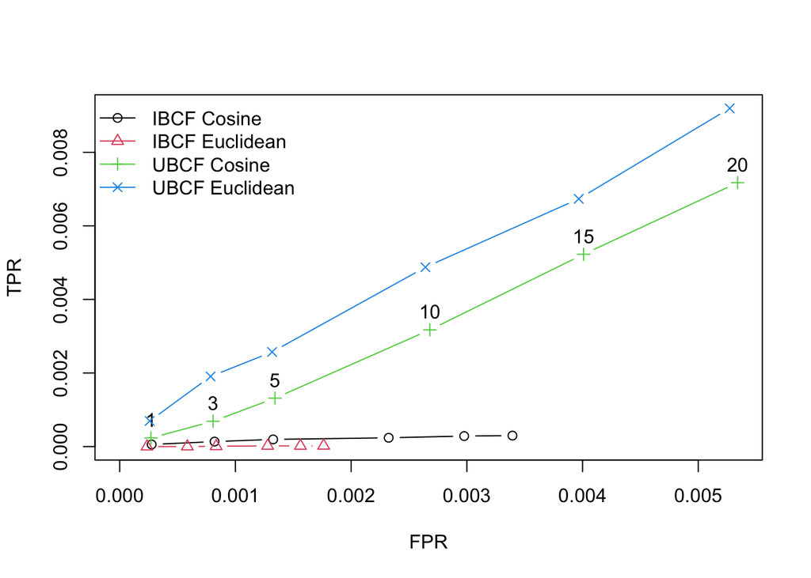

```r
plot(results, annotate=3, legend="topleft")
```